# Predicting Quality of Execution of Weight Lifting Exercise

Practical Machine Learning Course Project

Felix Schneider

7/31/2020

# 1 Introduction

The purpose of this analysis is to use accelerometer data measured on belt, arm, forearm and dumbbell of 6 individuals performing barbell lifts. The participants are asked to perform the lifts correctly as well as incorrectly in 4 different manners. The goal of the analysis is to predict the manner in which they performed the exercise from data that were not used in building the model.

# 2 The Data

## 2.1 Source

The data come from the following source: http://groupware.les.inf.puc-rio.br/har

> Velloso, E.; Bulling, A.; Gellersen, H.; Ugulino, W.; Fuks, H. Qualitative Activity Recognition of Weight Lifting Exercises. Proceedings of 4th International Conference in Cooperation with SIGCHI (Augmented Human ’13) . Stuttgart, Germany: ACM SIGCHI, 2013.

> Read more: http://groupware.les.inf.puc-rio.br/har#wle_paper_section#ixzz6UVzQ1xJp

First, the data is downloaded and loaded into R data frames.

```r
trainURL <- "https://d396qusza40orc.cloudfront.net/predmachlearn/pml-training.csv"
testURL  <- "https://d396qusza40orc.cloudfront.net/predmachlearn/pml-testing.csv"
download.file(trainURL,"pml-training.csv")
download.file(testURL, "pml-testing.csv")
pml_training <- read.csv("pml-training.csv",na.strings=c("NA","#DIV/0!"))
pml_testing  <- read.csv("pml-testing.csv", na.strings=c("NA","#DIV/0!"))
```

The data frames have the following dimensions.

```r
dim(pml_training)
```

```
## [1] 19622   160
```

```r
dim(pml_testing)
```

```
## [1]  20 160
```

The training data have 19622 observations and 160 variables, and the testing data have 20 observations and 160 variables.

## 2.2 Missing Values

Check whether there are *any* missing values (`NA`s).

```r
any(is.na(pml_training))
```

```
## [1] TRUE
```

```r
any(is.na(pml_testing))
```

```
## [1] TRUE
```

In fact, there *are* any missing values (`NA`s) in both the training and testing data sets.

Are there **any** columns that are **all** `NA`s?

```r
all_NA <- function(x) all(is.na(x))
pml_training %>% sapply(all_NA) %>% any()
```

```
## [1] TRUE
```

```r
pml_testing %>% sapply(all_NA) %>% any()
```

```
## [1] TRUE
```

In fact there *are* **any** columns in `pml_training` and `pml_testing` that are **all** NA.

How many columns have a certain number of NAs?

```r
table(colSums(is.na(pml_training)))
```

```
##
##     0 19216 19217 19218 19220 19221 19225 19226 19227 19248 19293 19294 19296
##    60    67     1     1     1     4     1     4     2     2     1     1     2
## 19299 19300 19301 19622
##     1     4     2     6
```

```r
table(colSums(is.na(pml_testing)))
```

```
##
##   0  20
##  60 100
```

In `pml_testing` all columns are either *no* `NA`s (`60` columns) or *all* `NA`s (`100` columns). In `pml-training` there are relatively few different values of the number of `NA`s. There are only 60 columns that have *no* `NA`s. 67 columns have 19216 `NA`s. And 6 columns have 19622 `NA`s, i.e. the number of observations in the data set.

Because we want to use only those variables for training the model that are provided for prediction in the *Course Project Prediction Quiz*, we remove the variables that are `NA` in the pml_**testing** set. The resulting data frames are called `train_notNA` and `quiz` respectively.

```r
notNA <- colSums(is.na(pml_testing))==0
train_notNA <- pml_training[,notNA][,-1] # remove first column 'X'
quiz  <- pml_testing[,notNA][,-1] # remove first column 'X'
```

# 3 The Features

## 3.1 Measured Variables

The label `classe` assumes one of 5 distinct values.

```r
unique(train_notNA$classe)
```

```
## [1] "A" "B" "C" "D" "E"
```

The labels correspond to the following manners of executions of the weight lifting exercise.

| label | execution |
| --- | --- |
| A | correct execution |
| B | throwing elbows to the front |
| C | lifting dumbbell only halfway |
| D | lowering dumbbell only halfway |
| E | throwing the hips to the front |

The variables come from 4 sensors (IMUs, Inertial Measurement Unit) mounted on

1. arm
2. forearm
3. belt
4. dumbbell

of the participants.

Each IMU measured the 3 cartesian components (`x`,`y`,`z`) of three different quantities:

1. linear acceleration (`accel`)
2. angular acceleration (`gyros`)
3. earth magnetic field (`magnet`)

Further, the orientation of the IMU was measured with the 3 angles

1. roll
2. pitch
3. yaw

Finally, 8 derived quantities are calculated

1. mean (`avg`)
2. variance (`var`)
3. standard deviation (`stddev`)
4. minimum (`min`)
5. maximum (`max`)
6. amplitude (`amplitude`)
7. kurtosis (`kurtosis`)
8. skewness (`skewness`)

## 3.2 Selected Features

From the columns without `NA`s, select the measured variables as features.

```r
names(train_notNA)
```

```
##  [1] "user_name"            "raw_timestamp_part_1" "raw_timestamp_part_2"
##  [4] "cvtd_timestamp"       "new_window"           "num_window"
##  [7] "roll_belt"            "pitch_belt"           "yaw_belt"
## [10] "total_accel_belt"     "gyros_belt_x"         "gyros_belt_y"
## [13] "gyros_belt_z"         "accel_belt_x"         "accel_belt_y"
## [16] "accel_belt_z"         "magnet_belt_x"        "magnet_belt_y"
## [19] "magnet_belt_z"        "roll_arm"             "pitch_arm"
## [22] "yaw_arm"              "total_accel_arm"      "gyros_arm_x"
## [25] "gyros_arm_y"          "gyros_arm_z"          "accel_arm_x"
## [28] "accel_arm_y"          "accel_arm_z"          "magnet_arm_x"
## [31] "magnet_arm_y"         "magnet_arm_z"         "roll_dumbbell"
## [34] "pitch_dumbbell"       "yaw_dumbbell"         "total_accel_dumbbell"
## [37] "gyros_dumbbell_x"     "gyros_dumbbell_y"     "gyros_dumbbell_z"
## [40] "accel_dumbbell_x"     "accel_dumbbell_y"     "accel_dumbbell_z"
## [43] "magnet_dumbbell_x"    "magnet_dumbbell_y"    "magnet_dumbbell_z"
## [46] "roll_forearm"         "pitch_forearm"        "yaw_forearm"
## [49] "total_accel_forearm"  "gyros_forearm_x"      "gyros_forearm_y"
## [52] "gyros_forearm_z"      "accel_forearm_x"      "accel_forearm_y"
## [55] "accel_forearm_z"      "magnet_forearm_x"     "magnet_forearm_y"
## [58] "magnet_forearm_z"     "classe"
```

```r
features <- names(train_notNA)[7:58]
```

```r
train <- train_notNA %>%
  select(features,classe) %>%
  mutate(classe=factor(classe))
X_quiz <- quiz %>%
  select(features)
```

The `train` data set is contains the target variable `classe` to be able to use the *formula* interface of the `train` command. The `X_quiz` data set obviously does not contain a target variable since this is to be predicted.

To visualize the `train` data set, an image is plotted. Before plotting, the data are scaled.

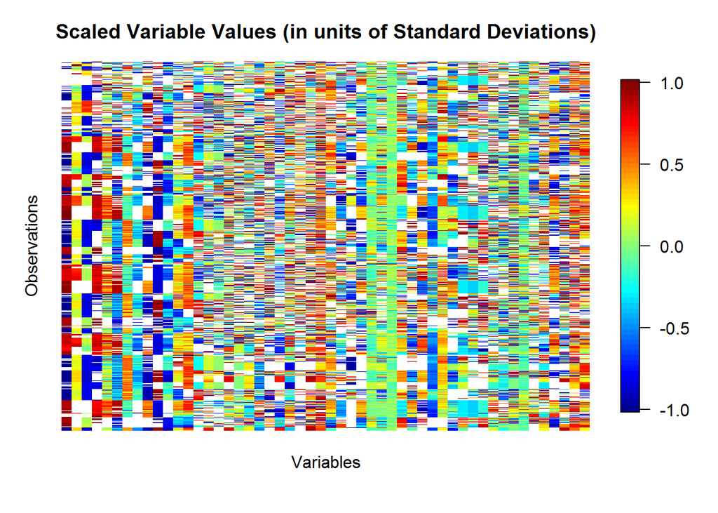

```r
opar <- par(mar=c(4,3,3,2),mgp=c(1,1,0))
train[,-53] %>%
  as.matrix() %>% # the 'image.plot()' function requires a 'matrix'
  scale() %>%
  t() %>%
  image.plot(zlim=c(-1,1)
             ,axes=FALSE
             # ,par=list(mar=c(1,3,3,3))
             )
title(main="Scaled Variable Values (in units of Standard Deviations)",
      xlab="Variables",
      ylab="Observations")
```

```r
par(opar)
```

# 4 Algorithm

## 4.1 Model

The following questions should be addressed in this report:

- *How is the model built?*
- *How is cross validation used?*
- *What is the expected out-of-sample error?*
- *Why were these choices made?*

The problem is a *multiclass* classification problem. Since accuracy is a major requirement, and speed is less of a concern, I decide to use a **Random Forest** model.

I am not sure if the `Accuracy` data that the `train` command generates are *out-of-sample* errors, so I set aside an evaluation data set to evaluate out-of-sample error. The data set that is used to build the model is called `build` and the data set that is used to evaluate the out-of-sample error is called `evalu`.

```r
inBuild <- createDataPartition(y=train$classe, p=0.8, list=FALSE)
build <- train[ inBuild,]
evalu <- train[-inBuild,]
```

Set resampling method to `"cv"` for cross validation. The tunig parameter is `mtry` the number of predictors used for fitting the model. No preprocessing is used. I use 5 Cross Validation hold-out samples.

```r
ctrl <- trainControl(method="cv",
                     number=5, # number of Cross Validation hold-out samples
                     # repeats=2, # no meaning for method="cv"
                     # preProcOptions=list(thresh=0.95),
                     verboseIter=TRUE,
                     returnResamp="all",
                     savePredictions="final",
                     timingSamps=100)
```

The multicore cluster is initialized and registered for parallel execution. The current time is recorded in `tic` to measure elapsed time after completion of training.

```r
cl <- makePSOCKcluster(8)
registerDoParallel(cl)
tic <- Sys.time()
```

I chose the train method `parRF` because I want to plot Variable Importance and this method provides this because it requires the package `RandomForest` which creates a model object that accepts the `importance=TRUE` parameter. To see the performance of the model building process across the tuning parameter, I choose `tuneLength=6` to get Accuracy values for 6 different values of `mtry`, instead of the default which is 3.

```r
model <- train(classe~., data=build,
               method="parRF",
               # preProcess=c("center","scale","nzv"),
               trControl=ctrl,
               importance=TRUE,
               tuneLength=6)
## Aggregating results
## Selecting tuning parameters
## Fitting mtry = 12 on full training set
```

I record the current time `toc`, stop the multicore cluster and print the elapsed time.

```r
toc <- Sys.time()
stopCluster(cl)
print(toc-tic)
## Time difference of 13.12247 mins
```

As a check, I print the values that the training process recorded for timing. I am not sure how parallel execution is reflected in the times.

```r
model$times
```

```
## $everything
##    user  system elapsed
##    2.73    0.42  785.20
##
## $final
##    user  system elapsed
##    1.72    0.42   28.59
##
## $prediction
##    user  system elapsed
##    0.05    0.02    0.06
```

The results of the training process are as follows.

```r
model
## Parallel Random Forest
##
## 15699 samples
##    52 predictor
##     5 classes: 'A', 'B', 'C', 'D', 'E'
##
## No pre-processing
## Resampling: Cross-Validated (5 fold)
## Summary of sample sizes: 12560, 12560, 12558, 12559, 12559
## Resampling results across tuning parameters:
##
##   mtry  Accuracy   Kappa
##    2    0.9929932  0.9911362
##   12    0.9938213  0.9921841
##   22    0.9929931  0.9911364
##   32    0.9908911  0.9884769
##   42    0.9885344  0.9854949
##   52    0.9845853  0.9804993
##
## Accuracy was used to select the optimal model using the largest value.
## The final value used for the model was mtry = 12.
```

The Accuracy over the different number of predictors is plotted as follows.

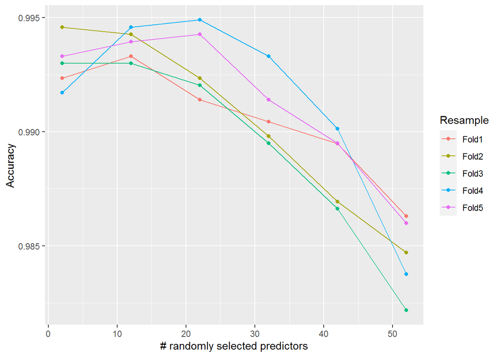

```r
qplot(x=mtry, y=Accuracy, data=model$resample,
      color=Resample,
      geom=c("line","point"),
      # geom=c("boxplot"),
      # fill=Resample,
      xlab="# randomly selected predictors")
```

One can see from the numbers and from the plot that the accuracy varies only in a very narrow band across the number of randomly selected predictors.

The importance of variables is plotted as follows.

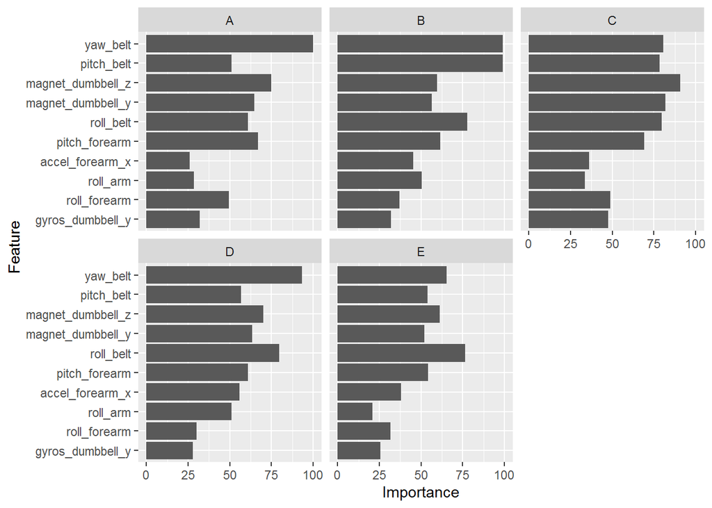

```r
ggplot(varImp(model), top=10)
```

## 4.2 Out-Of-Sample Error

To get an estimate for the out-of-sample error, the model is predicted for the hold-out data `evalu`. With the prediction, a Confusion Matrix is constructed.

```r
X_evalu <- select(evalu,-classe)
confMat <- confusionMatrix(predict(model,X_evalu),evalu$classe)
confMat
## Confusion Matrix and Statistics
##
##           Reference
## Prediction    A    B    C    D    E
##          A 1116    2    0    0    0
##          B    0  756    2    0    0
##          C    0    1  682    8    1
##          D    0    0    0  635    1
##          E    0    0    0    0  719
##
## Overall Statistics
##
##                Accuracy : 0.9962
##                  95% CI : (0.9937, 0.9979)
##     No Information Rate : 0.2845
##     P-Value [Acc > NIR] : < 2.2e-16
##
##                   Kappa : 0.9952
##
##  Mcnemar's Test P-Value : NA
##
## Statistics by Class:
##
##                      Class: A Class: B Class: C Class: D Class: E
## Sensitivity            1.0000   0.9960   0.9971   0.9876   0.9972
## Specificity            0.9993   0.9994   0.9969   0.9997   1.0000
## Pos Pred Value         0.9982   0.9974   0.9855   0.9984   1.0000
## Neg Pred Value         1.0000   0.9991   0.9994   0.9976   0.9994
## Prevalence             0.2845   0.1935   0.1744   0.1639   0.1838
## Detection Rate         0.2845   0.1927   0.1738   0.1619   0.1833
## Detection Prevalence   0.2850   0.1932   0.1764   0.1621   0.1833
## Balanced Accuracy      0.9996   0.9977   0.9970   0.9936   0.9986
```

The proportions in the Confusion Matrix are plotted.

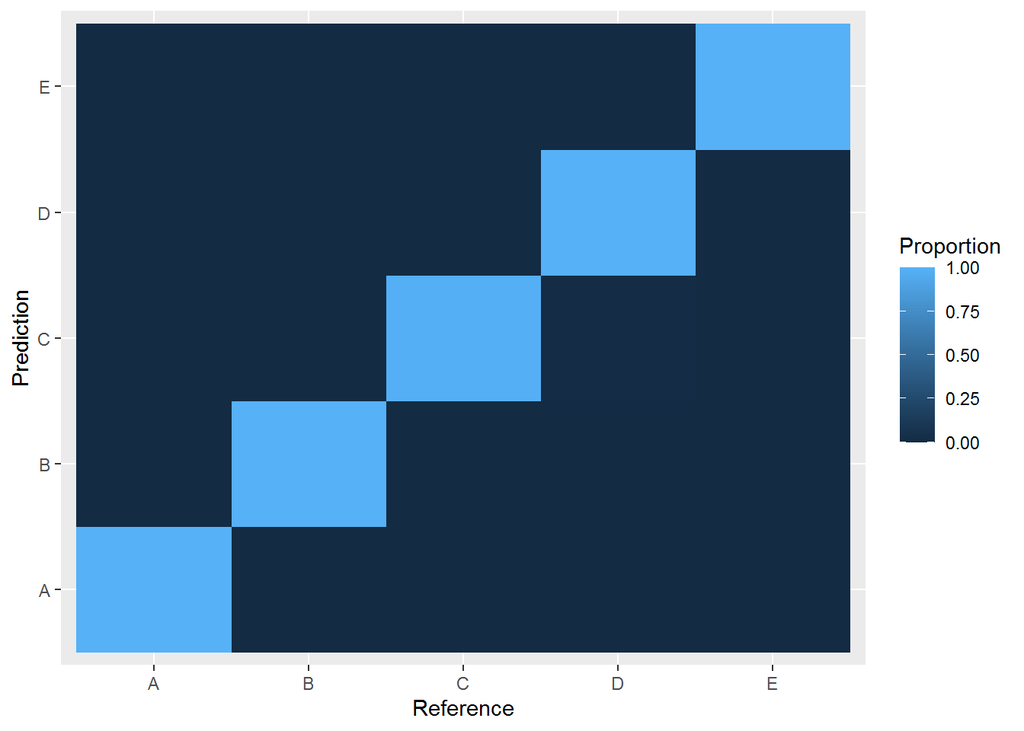

```r
qplot(data=as.data.frame(proportions(confMat$table, margin=1), responseName="Proportion"),
      x=Reference, y=Prediction,
      geom="raster", fill=Proportion)
```

The plot visualizes the high accuracy of the out-of-sample prediction which is an indication that the model has **no overfitting**.

# 5 Prediction

The data records that are to be reported in the Quiz are predicted. The results are hidden since they are evaluated by the Quiz.

```r
prediction <- predict(model,X_quiz)
prediction
```